# Sujet 8

Group4 4Infini3

Sarra Ayari/ Arij Aouadi/ Sinda Hamdi/ Donia Aloulou/ Kalthoum Zaiter/ Mohamed Aziz Marzouki

On se propose d’estimer et de projeter la mortalité d’une cohorte d’assurés italiens afin d’étudier un contrat de retraite et un produit de capital décès. Plus précisément, on suppose que l’assureur possède un portefeuille d’assurés ayant contracté en 2015 (à l’âge de 40 ans) deux types de contrats : - Un contrat de retraite pour lequel l’assuré recevra un rentre de R = 1500 euros à partir de l’âge de 65 ans, et paiera une prime annuelle jusqu’à 65 ans.- Un contrat de capital décès pour lequel les bénéficiaires de l’assuré recevront un capital de K = 100 000 euros en échange du paiement d’une prime annuelle par l’assuré.

### Chargement des packages

```r
library(StMoMo)
library(lifecontingencies)
library(reliaR)
library(demography)
library(fanplot)
```

### Téléchargement des données pour l’Italie

```r
mortality_data <- read.csv("LifeTable.csv")
head(mortality_data)
```

|  | Year | Age | mx | qx | ax | lx | dx | Lx | Tx | ex |
| --- | --- | --- | --- | --- | --- | --- | --- | --- | --- | --- |
| 1 | 1872 | 0 | 0.27852 | 0.23341 | 0.31 | 100000 | 23341 | 83803 | 2976426 | 29.76 |
| 2 | 1872 | 1 | 0.13716 | 0.12836 | 0.50 | 76659 | 9840 | 71739 | 2892623 | 37.73 |
| 3 | 1872 | 2 | 0.09317 | 0.08902 | 0.50 | 66819 | 5949 | 63845 | 2820884 | 42.22 |
| 4 | 1872 | 3 | 0.05408 | 0.05266 | 0.50 | 60871 | 3205 | 59268 | 2757039 | 45.29 |
| 5 | 1872 | 4 | 0.03534 | 0.03473 | 0.50 | 57666 | 2003 | 56664 | 2697770 | 46.78 |
| 6 | 1872 | 5 | 0.02420 | 0.02391 | 0.50 | 55663 | 1331 | 54998 | 2641106 | 47.45 |

```r
ITA <- hmd.mx(country = "ITA",username = "arij.aouadi@esprit.tn",password = "nin#jy7t4XAAeJv",label = "Italy")
```

### Les taux de mortalité de l’année 2015.

```r
x <- ITA$age[40:110]


plot(x, ITA$rate$female[40:110,"2015"],
     type='l',
     col='red',
     xlab= "Ages x",
     ylab="mortality rate",
     ylim=c(0.0,1),
     main ="Taux de mortalite 2015 (femme/homme) ")

lines(x, ITA$rate$male[40:110,"2015"], type = 'l', col="blue" )
```

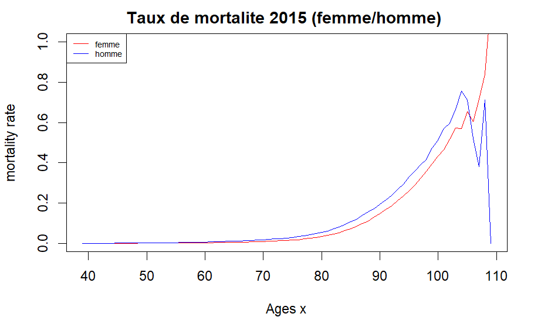

```r
legend(x="topleft",
       legend = c("femme","homme"),
       col = c("red","blue"),
       lty = 1,
       cex=0.6,
       box.lwd = 0.3)
```

### PROVISIONS MATHÉMATIQUES

Pour Calculer la VAP des deux produits (à la date de début du contrat) en utilisant pour mortalité de référence les taux de 2016 on va utilisé une table de mortalité pour l’année 2016.

```r
mortality_data_of_2016<- mortality_data[which(mortality_data$Year == 2016),names(mortality_data)]
head(mortality_data_of_2016)
```

|  | Year | Age | mx | qx | ax | lx | dx | Lx | Tx | ex |
| --- | --- | --- | --- | --- | --- | --- | --- | --- | --- | --- |
| 15985 | 2016 | 0 | 0.00281 | 0.00281 | 0.14 | 100000 | 281 | 99760 | 8305174 | 83.05 |
| 15986 | 2016 | 1 | 0.00017 | 0.00017 | 0.50 | 99719 | 17 | 99711 | 8205415 | 82.29 |
| 15987 | 2016 | 2 | 0.00008 | 0.00008 | 0.50 | 99702 | 8 | 99698 | 8105704 | 81.30 |
| 15988 | 2016 | 3 | 0.00009 | 0.00009 | 0.50 | 99694 | 9 | 99690 | 8006005 | 80.31 |
| 15989 | 2016 | 4 | 0.00006 | 0.00006 | 0.50 | 99685 | 6 | 99682 | 7906316 | 79.31 |
| 15990 | 2016 | 5 | 0.00007 | 0.00007 | 0.50 | 99679 | 7 | 99676 | 7806633 | 78.32 |

```r
df_Ita2016<-data.frame(mortality_data_of_2016)
str(df_Ita2016$Age)
```

```
 chr [1:111] "0" "1" "2" "3" "4" "5" "6" "7" "8" "9" "10" "11" "12" ...
```

```r
df_Ita2016$Age<-as.numeric(as.character(df_Ita2016$Age))
df_Ita2016$Age[111]<-110
str(df_Ita2016$Age)
```

```
 num [1:111] 0 1 2 3 4 5 6 7 8 9 ...
```

```r
TD2016 <- new("lifetable", x=df_Ita2016$Age, lx= df_Ita2016$lx,name="Italy")
i=(1/0.97-1)
TD2016tb <- new("actuarialtable", x=TD2016@x, lx=TD2016@lx,interest=i)
```

### VAP du Capital au décès avec prime annuelle

Vap_capannu est la fonction R permettant de calculer la VAP du Capital au décès avec prime annuelle à partir d’une table de mortalité.

Pour la fonction Vkx.capannu(x, k, K) :

x : L’âge de l’assuré au moment du contrat. k : Le nombre d’années écoulées depuis le début du contrat jusqu’à la date de valorisation (à laquelle vous souhaitez calculer la VAP). K : Le capital décès pour lequel les bénéficiaires recevront un montant en euros.

```r
Vkx.capannu <- function(x, k, K)
{
  prem <- Axn(TD2016tb, x=x)*K / axn(TD2016tb, x=x, m=0)
  K * Axn(TD2016tb, x=x+k) - prem * axn(TD2016tb, x=x+k, m=0)
}
```

### VAP du Contrat de retraite

Vkx.retraite est la fonction R permettant de calculer la VAP du Contrat de retraite à partir d’une table de mortalité.

Pour la fonction Vkx.retraite(x, n, k, R) :

x : L’âge de l’assuré au moment du contrat. n : L’âge de départ à la retraite (par exemple, 65 ans). k : Le nombre d’années écoulées depuis le début du contrat jusqu’à la date de valorisation. R : Le montant de la rente en euros que l’assuré recevra à partir de l’âge de départ à la retraite.

```r
Vkx.retraite <- function(x, n, k, R)
{
  prem <- axn(TD2016tb, x=x, m=n-x)*R / axn(TD2016tb, x=x, m=0, n=n-x)
  k1 <- k[k < n-x]
  k2 <- k[k >= n-x]
  res <- axn(TD2016tb, x=x+k, m=n-x-k)*R - prem * axn(TD2016tb, x=x+k, m=0, n=n-x-k)
  c(res, axn(TD2016tb, x=x+k)*R)
}
```

### Application Numérique

Pour Un contrat de capital décès pour lequel les bénéficiaires de l’assuré recevront un capital de K = 100 000 euros en échange du paiement d’une prime annuelle par l’assuré pour calculer la VAP du produit à la date de début du contrat (k = 0), on utilise la fonction Vkx.capannu de la manière suivante :

```r
vap_capannulle <- Vkx.capannu(40, 0, 100000)
print(vap_capannulle)
```

```
[1] 3.637979e-12
```

Un contrat de retraite pour lequel l’assuré recevra un rentre de R = 1500 euros à partir de l’âge de 65 ans, et paiera une prime annuelle jusqu’à 65 ans pour calculer la VAP du contrat de retraite à la date de début du contrat, on utilise la fonction Vkx.retraite comme suit :

```r
vap_retraite <- Vkx.retraite(40, 65, 0, 1500)
print(vap_retraite)
```

```
[1]     0.00 36176.89
```

## Projection de la mortalité par le modèle de Lee-Carter

### Choix de la période de calibration des données :

```r
par(mfrow=c(1,1))
ITA_ages = c(0,10,20,30,40,50,60,70,80,90,100)

plot(ITA,
     datatype="rate",
     plot.type="time",
     age = ITA_ages,
     main="Taux de mortalité (1922 - 2018) ",axes = F)
# on fixe les axes comme suit :
axis(side = 1, at=1910:2020)
```

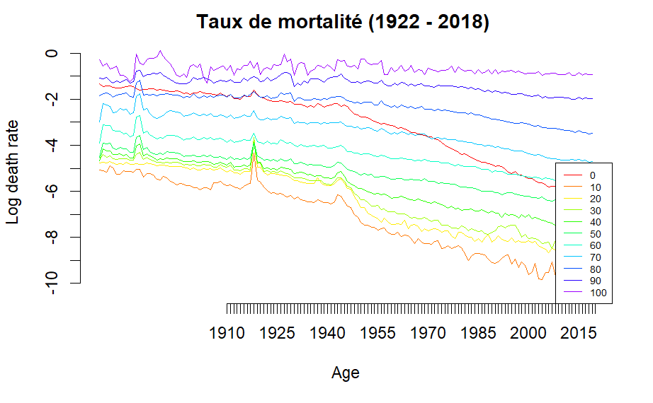

```r
axis(side = 2, at=-10:0)
legend(x="bottomright", legend = ITA_ages,
       col = rainbow(length(ITA_ages)*1.25), lty = 1, cex=0.6,
       box.lwd = 0.3)
```

```r
NA
NA
```

### Le choix de la plage d’âge

```r
x <- ITA$age[0:110]


plot(x, ITA$rate$total[0:110,"1960"],
     type='l',
     col='red',
     xlab= "Ages x",
     ylab="volatility",
     ylim=c(0,1.5),
     main ="Volatilité des taux de mortalité (1960,2018)")

lines(x, ITA$rate$total[0:110,"1960"], type = 'l', col="green" )
```

```r
lines(x, ITA$rate$total[0:110,"1975"], type = 'l', col='orange' )
lines(x, ITA$rate$total[0:110,"1980"], type = 'l', col="blue" )
```

```r
lines(x, ITA$rate$total[0:110,"1990"], type = 'l', col="red" )
lines(x, ITA$rate$total[0:110,"2000"], type = 'l', col='purple' )
```

```r
lines(x, ITA$rate$total[0:110,"2010"], type = 'l', col="yellow" )
lines(x, ITA$rate$total[0:110,"2014"], type = 'l', col="pink" )
```

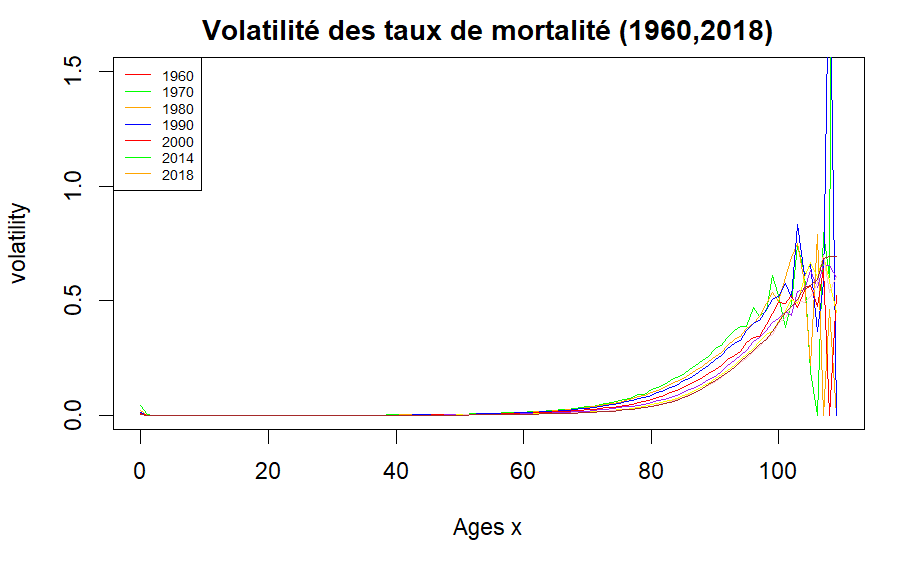

```r
lines(x, ITA$rate$total[0:110,"2018"], type = 'l', col='brown' )



legend(x="topleft",
       legend = c("1960","1970","1980","1990","2000","2014","2018"),
       col = c("red","green","orange","blue"),
       lty = 1,
       cex=0.6,
       box.lwd = 0.3)
```

Des taux de mortalité pour les âges > 100 c’est pour cette raison que nous allons nous limiter à x ∈ [0, 100].

### Les paramètres estimés.

```r
#plage d'âges
ages.fit = 0:100
#période de calibration
years.fit = 1922:2018
```

```r
# Lissage :
## 1- Spline monotone :
ITA_ls_m <- smooth.demogdata(ITA,method="mspline")
## 2- Spline standard :
ITA_ls_s <- smooth.demogdata(ITA, method="spline")
## 3- Spline Concave :
ITA_ls_c <- smooth.demogdata(ITA, method="cspline")
## 4- Spline localement quadratique :
ITA_ls_q <- smooth.demogdata(ITA, method="loess")
```

```r
# comparaison :
plot(ITA, years=2018, type="p", pch=21, ylim=c(-12, -2), main="ITA: MT 2018 - Lissage")
lines(ITA_ls_m, years=2018, lty=1, col="blue")
```

```r
lines(ITA_ls_s, years=2018, lty=2, col="red")
lines(ITA_ls_c, years=2018, lty=3, col="green")
```

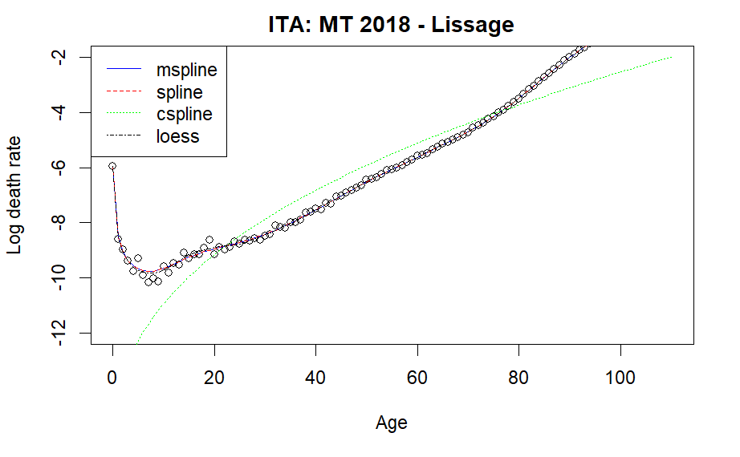

```r
lines(ITA_ls_q, years=2018, lty=4, col="black")
legend("topleft",col=c("blue","red","green","black") ,lty=1:4, leg=c("mspline", "spline","cspline","loess"))
```

spline représente le mieux la variation du taux de mortalité on peut choisir l’un des deux.

### Fitting Lee Carter model :

```r
lca <- lca(ITA_ls_m, adjust="dt",years =years.fit ,ages = ages.fit)
```

## Analyse des paramètres :

#### Paramètre αx :

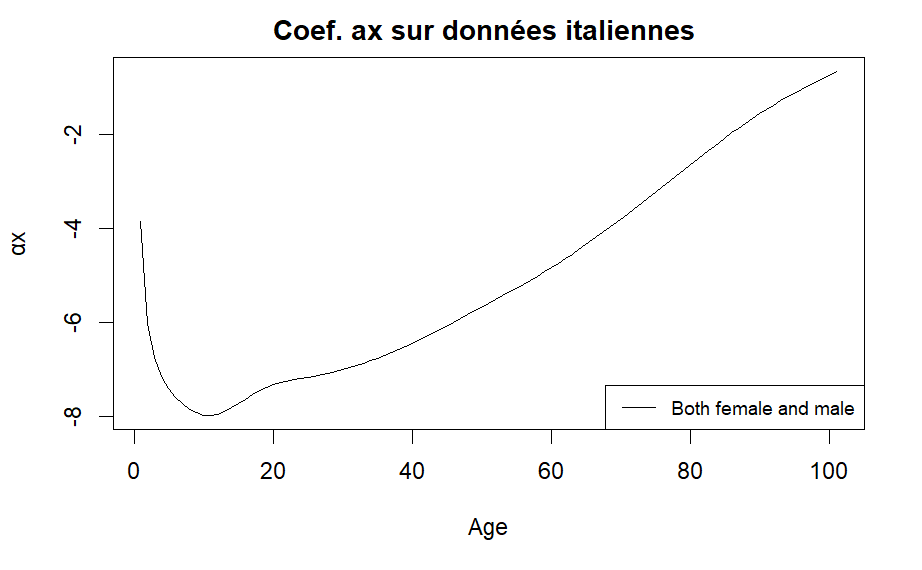

```r
plot(lca$ax, main="Coef. ax sur données italiennes ", xlab="Age", ylab="αx", type="l")
legend("bottomright", c("Both female and male"), cex=0.8,  lty=1:2)
```

En utilisant ce paramètre “ax”, le modèle de Lee-Carter permet de modéliser et de prévoir les taux de mortalité à chaque âge en fonction du temps. Cela peut être utile pour comprendre les tendances de mortalité, évaluer les risques de décès dans des populations spécifiques, et estimer les probabilités de survie pour des questions d’assurance et de planification des retraites, entre autres.

#### Paramètre βx :

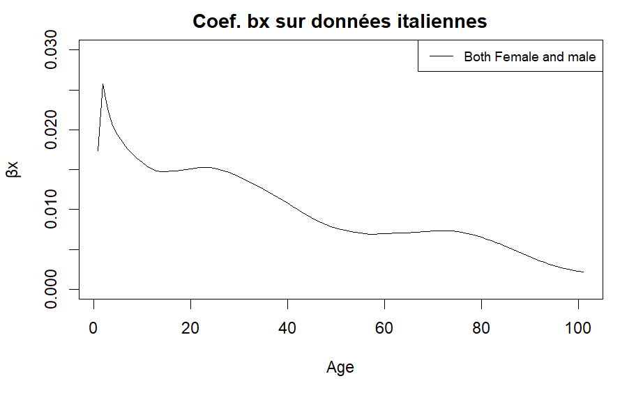

```r
plot(lca$bx, main="Coef. bx sur données italiennes", ylim=c(0,0.03),xlab="Age", ylab="βx", type="l")
legend("topright",c("Both Female and male"), cex=0.8,  lty=1:2)
```

Les coefficients de pente spécifiques à chaque âge “bx” sont estimés à partir des données historiques de mortalité en utilisant des techniques d’ajustement des données, telles que la régression linéaire ou d’autres méthodes statistiques. Ces coefficients permettent de modéliser et de projeter l’évolution temporelle des taux de mortalité à chaque âge dans le modèle de Lee-Carter.

#### Paramètre kt :

```r
plot(lca$kt, xlab="Year", main="Coef. kt sur données italiennes",ylab="kt", type="l",ylim=c(-100, 100))
lines(lca$year, y=lca$kt, main="kt", lty=2 , col ="red")
```

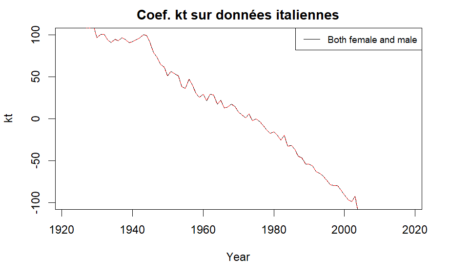

```r
legend("topright", c("Both female and male"), cex=0.8, lty=1:2)
```

### résidus et résultats.

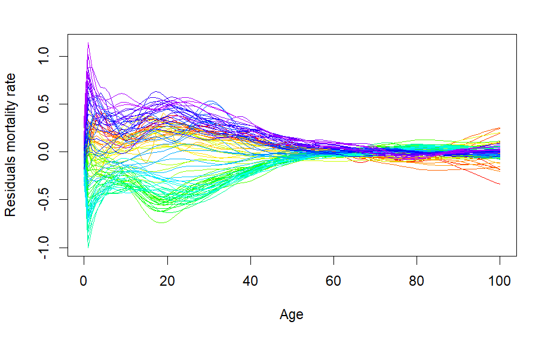

```r
plot(lca$residuals)
```

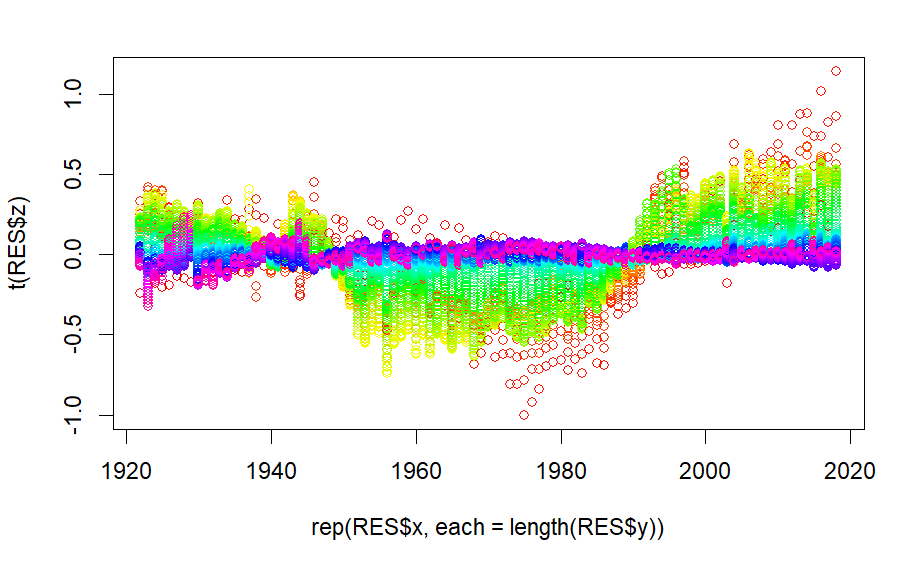

```r
RES=residuals(lca,"pearson")
colr=function(k) rainbow(110)[k*100]
couleur=Vectorize(colr)(seq(.01,1,by=.01))
plot(rep(RES$x,each=length(RES$y)),t(RES$z),col=couleur[rep(RES$y,length(RES$x))+1])
```

### En utilisant la fonction fit du package “““StMoMo”“” :

```r
ITA.stmomo.f<-StMoMoData(data=ITA_ls_m ,type="central")
#ajustement du model (fitiing) :
LC3 <- lc(link = "logit" )
LCfit3 <- fit(LC3, data = central2initial(ITA.stmomo.f), ages.fit = ages.fit,  years.fit = years.fit)
```

```
StMoMo: Start fitting with gnm
Initialising
Running start-up iterations..
Running main iterations.........
Done
StMoMo: Finish fitting with gnm
```

### analyse des résidus :

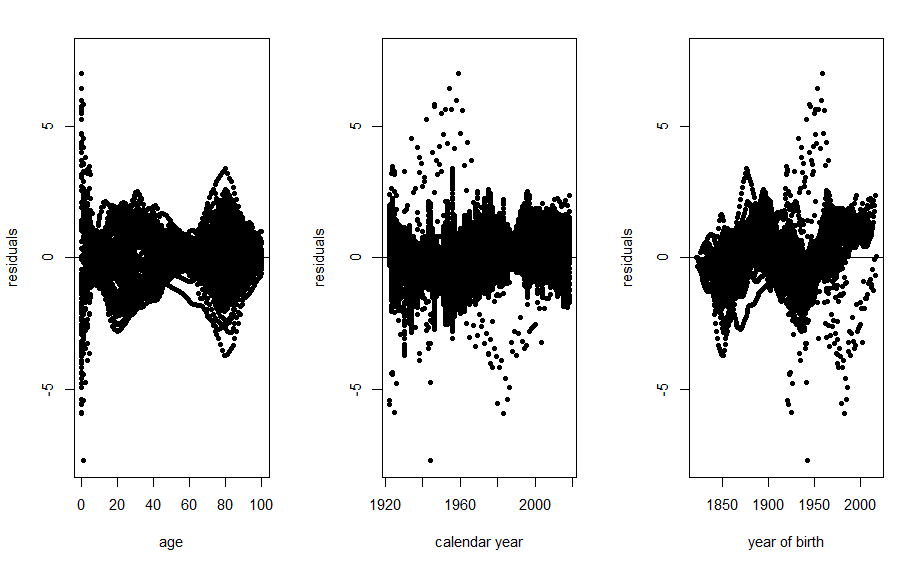

```r
LCres3 <- residuals(LCfit3)
plot(LCres3,type = "scatter")
```

En utilisant ce modèle, le programme génère des simulations de trajectoires futures de mortalité pour l’échantillon, en prenant en compte à la fois les tendances historiques et les fluctuations aléatoires. Ces simulations permettent d’explorer différentes hypothèses et scénarios de mortalité pour l’échantillon.

```r
ITASim <- simulate(LCfit3 , h = 25, method=mean,nsim=5000)
print(ITASim)
```

```
Simulations of Stochastic Mortality Model
Call: simulate.fitStMoMo(object = LCfit3, nsim = 5000, h = 25, method = mean)

Simulation based on
Call: fit.StMoMo(object = LC3, data = central2initial(ITA.stmomo.f),
Call:     ages.fit = ages.fit, years.fit = years.fit)

kt model: mrwd
Jump-off method: fit
Years in simulation: 2019 - 2043
Ages in simulation: 0 - 100

Number of paths: 5000
```

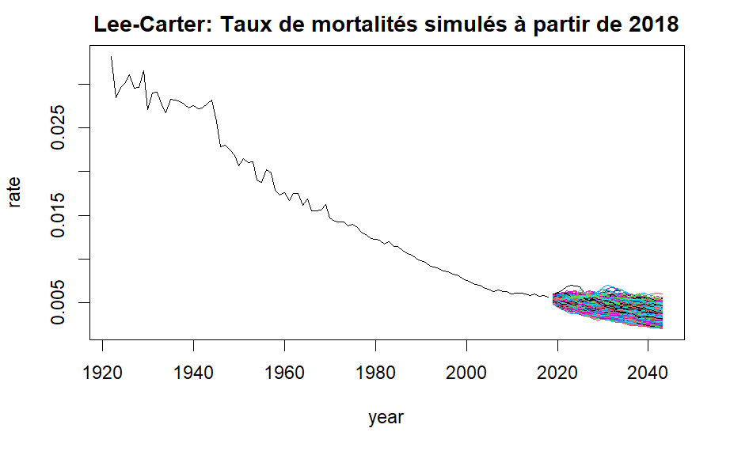

```r
plot(LCfit3$years, (LCfit3$Dxt / LCfit3$Ext)["65", ],
     xlim = range(LCfit3$years, ITASim$years),
     ylim = range((LCfit3$Dxt / LCfit3$Ext)["65", ], ITASim$rates["65", , ]),
     type = "l", xlab = "year", ylab = "rate",
     main = "Lee-Carter: Taux de mortalités simulés à partir de 2018")
matlines(ITASim$years, ITASim$rates["65", , ], type = "l", lty = 1)
```

### Projetection des taux de mortalité à l’aide de la fonction forecast.

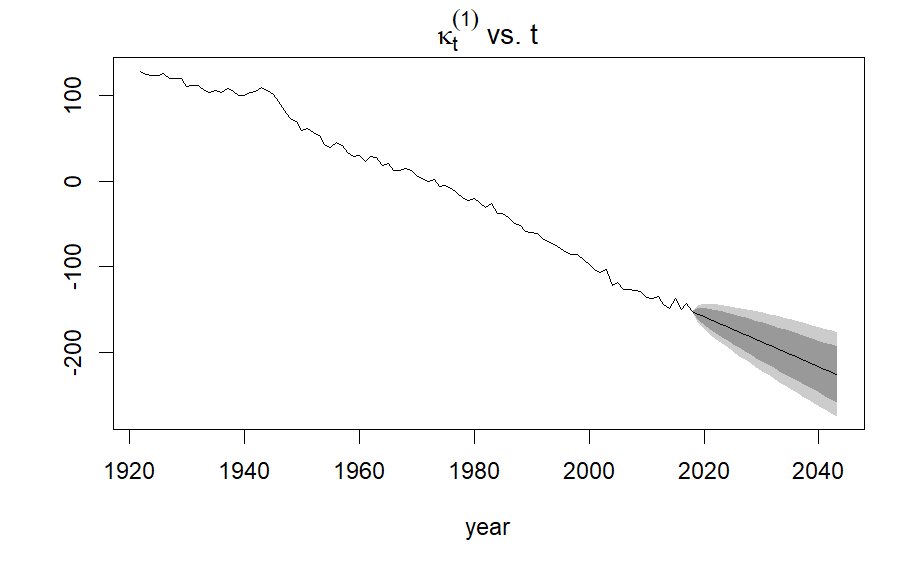

```r
ITALcaM <- lca(ITA_ls_m, max.age = 110, adjust="dt")

LcFore=forecast(ITALcaM, h = 25 ,method=mean)
SuisseForcast <- forecast(LCfit3 , h = 25, method=mean)
plot(SuisseForcast, only.kt=TRUE)
```

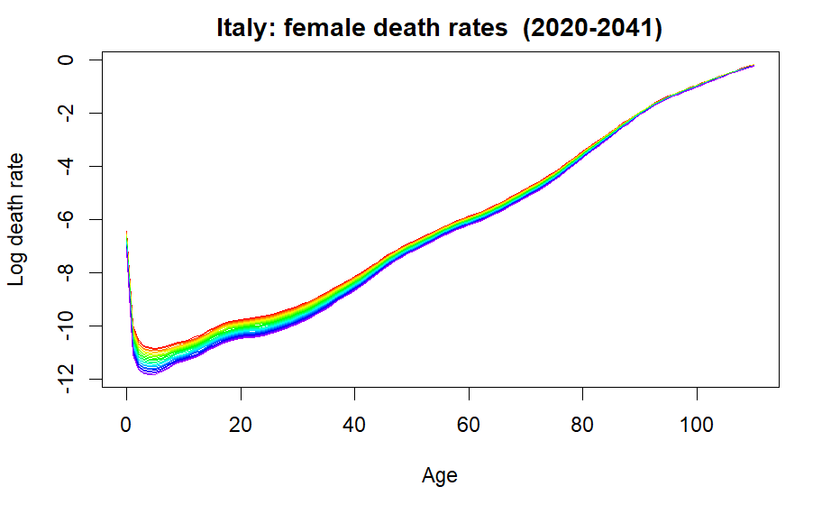

```r
ITA1841 <- extract.years(LcFore, years=2018:2041)
plot(ITA1841)
```